# homework

Shi Cheng

2021-12-19

## A—21041—2021—09—16

```r
# A program to calculate sum of Fibonacci sequence
x <- c()
x[1] <- 1
x[2] <- 1
s <- x[1] + x[2]
for (i in 3:10) {
  x[i] <- x[i-1] + x[i-2]
  s <- s + x[i]
  print(s)
}
```

```
## [1] 4
## [1] 7
## [1] 12
## [1] 20
## [1] 33
## [1] 54
## [1] 88
## [1] 143
```

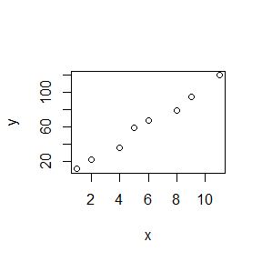

```r
# A program to give a scatter diagram of a linear regression equation
x <- c(1,6,5,8,4,2,9,11)
y <- c(11,68,59,79,36,22,95,120)
plot(x,y)
```

```r
# Using knitr & kable to produce a table of R data "mtcars"
library(knitr)
data <- head(mtcars)
kable(data)
```

|  | mpg | cyl | disp | hp | drat | wt | qsec | vs | am | gear | carb |
| --- | --- | --- | --- | --- | --- | --- | --- | --- | --- | --- | --- |
| Mazda RX4 | 21.0 | 6 | 160 | 110 | 3.90 | 2.620 | 16.46 | 0 | 1 | 4 | 4 |
| Mazda RX4 Wag | 21.0 | 6 | 160 | 110 | 3.90 | 2.875 | 17.02 | 0 | 1 | 4 | 4 |
| Datsun 710 | 22.8 | 4 | 108 | 93 | 3.85 | 2.320 | 18.61 | 1 | 1 | 4 | 1 |
| Hornet 4 Drive | 21.4 | 6 | 258 | 110 | 3.08 | 3.215 | 19.44 | 1 | 0 | 3 | 1 |
| Hornet Sportabout | 18.7 | 8 | 360 | 175 | 3.15 | 3.440 | 17.02 | 0 | 0 | 3 | 2 |
| Valiant | 18.1 | 6 | 225 | 105 | 2.76 | 3.460 | 20.22 | 1 | 0 | 3 | 1 |

## A—21041—2021—09—23

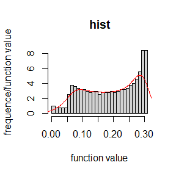

```r
# sigma = 2
f <- function(x, sigma = 2){
  (x/sigma^2)*exp(-x^2/(2*sigma^2))
  }
x <- seq(0, 5, .01)
dim(x) <- length(x)
y <- apply(x, 1, f)
hist(y, breaks = 40, freq = FALSE, main = "hist", xlab = "function value", ylab = "frequence/function value")
lines(density(y), col = "red")
```

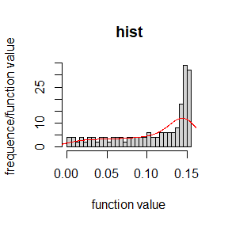

```r
# sigma = 4
f <- function(x, sigma = 4){
  (x/sigma^2)*exp(-x^2/(2*sigma^2))
  }
x <- seq(0, 5, length=100)
dim(x) <- length(x)
y <- apply(x, 1, f)
hist(y, breaks = 40, main = "hist", freq = FALSE, xlab = "function value", ylab = "frequence/function value")
lines(density(y), col = "red")
```

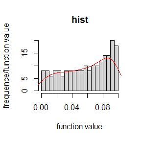

```r
# sigma = 6
f <- function(x, sigma = 6){
  (x/sigma^2)*exp(-x^2/(2*sigma^2))
  }
x <- seq(0, 5, length=100)
dim(x) <- length(x)
y <- apply(x, 1, f)
hist(y, breaks = 20, main = "hist", freq = FALSE, xlab = "function value", ylab = "frequence/function value")
lines(density(y), col = "red")
```

## A-21041-2021-09-30

### 5.4 Write a function to compute a Monte Carlo estimate of the Beta(3, 3) cdf……

```r
f <- function(x){
  m <- 10000
  t <- runif(m, min = 0, max = x)
  theta_hat  = x * mean((gamma(3 + 3)/(gamma(3) * gamma(3))) * t^2 * (1-t)^2)
}
for (i in seq(.1, .9, length = 9)){
  print(c(f(i), pbeta(i, 3, 3)))
}
```

```
## [1] 0.008649677 0.008560000
## [1] 0.05753747 0.05792000
## [1] 0.1599597 0.1630800
## [1] 0.3180713 0.3174400
## [1] 0.5002431 0.5000000
## [1] 0.6777754 0.6825600
## [1] 0.8349286 0.8369200
## [1] 0.93691 0.94208
## [1] 0.9922301 0.9914400
```

### 5.9 The Rayleigh density [156, (18.76)] is……

$$f(x) = \frac{x}{\sigma^2}e^{-\frac{x^2}{2\sigma^2}},x \geq 0,\sigma >0$$

$$F(x) = \int_{0}^x f(t)d t = \int_{0}^x\frac{t}{\sigma^2}e^{-t^2/(2\sigma^2)}dt= 1 - e^{-x^2/(2\sigma^2)}.$$

Hence:
$$F^{-1}(u) = \sqrt{-2\log(1-u)}\sigma, 0<u<1.$$

```r
#define function MC.anti() to withdraw samples from distribution Rayleigh with "antithetic" as the optional option
MC.anti <- function(x, sigma = 2, R = 10000, antithetic = TRUE){
  u <- runif(R/2)
  if (!antithetic)
    v <- runif(R/2)
  else
    v <- 1 - u
  u <- c(u, v)
  cdf <- numeric(length(x))
  for (i in 1:length(x)){
    g <- x[i]^2 / sigma^2 * u * exp(- x^2 * u^2 / (2 * sigma^2))
    cdf[i] = mean(g)
  }
  cdf
}

x <- seq(.1, 2.5, length = 5)
MC1 <- MC.anti(x, anti = FALSE)
MC2 <- MC.anti(x)

m <- 1000
MC1 <- MC2 <- numeric(m)
x <- 2
for (i in 1:m){
  MC1[i] <- MC.anti(x, R = 10000, anti = FALSE)
  MC2[i] <- MC.anti(x, R = 10000)
}
print(sd(MC1))
```

```
## [1] 0.001892144
```

```r
print(sd(MC2))
```

```
## [1] 0.0005856509
```

```r
print((var(MC1)-var(MC2))/var(MC1))
```

```
## [1] 0.9041992
```

#### The percent reduction in variance is about 90%(it changes every time you run the code)

### 5.13 Find two importance functions f1 and f2 that are supported on (1, ∞) and……

#### let $t=\frac{1}{x}$,we have

$$g(t)=\frac{1}{t^2\sqrt(2\pi)}e^{-\frac{1}{2t^2}},0<t<1$$
#### first,apply the method of substitution to transfer integration into
$$\int_{0}^{1}\frac{1}{t^4\sqrt{2\pi}}e^{-\frac{1}{2t^2}}dt$$

#### choose

$$f_1 = \frac{1}{x^2\sqrt{2\pi}}e^{\frac{x^5}{10}-\frac{1}{2x^2}}$$
$$f_2 = \frac{1}{x^5\sqrt{2\pi}}e^{-\frac{1}{2x^2}}$$

```r
m <- 10000
theta.hat <- se <- numeric(3)

#define function g(x)
g <- function(x){
  1 / (x**4 * sqrt(2 * pi)) * exp(-1 / (2 * x**2)) * (x>0) * (x<1)
}

#without importance function
x <- runif(m)
f0g <- g(x)
theta.hat[1] <- mean(f0g)
se[1] <- sd(f0g)

#when f1 is selected as the importance function
x <- runif(m)
f1g <- g(x) * exp(x**5/10)
theta.hat[2] <- mean(f1g)
se[2] <- sd(f1g)

#when f2 is selected as the importance function
x <- runif(m)
f2g <- g(x) * (1/x)
theta.hat[3] <- mean(f2g)
se[3] <- sd(f2g)

#show the estimation & se of each situation
rbind(theta.hat, se)
```

```
##                [,1]      [,2]      [,3]
## theta.hat 0.4034057 0.4039469 0.7229644
## se        0.3076316 0.3042510 0.6205628
```

#### It’s clear that when we choose f1 as the imporance function, we obtain a smaller variance,cause it’s se is smaller

### 5.14 Obtain a Monte Carlo estimate of

$$\int_{1}^{\infty}\frac{x^2}{\sqrt{2\pi}}e^{-\frac{x^2}{2}}dx$$

### by imporance sampling

#### first,apply the method of substitution to transfer integration into

$$\int_{0}^{1}\frac{1}{t^4\sqrt{2\pi}}e^{-\frac{1}{2t^2}}dt$$

#### choose

$$f = \frac{1}{x^2\sqrt{2\pi}}e^{\frac{x^5}{20}-\frac{1}{2x^2}}$$

```r
m <- 10000
theta.hat <- se <- numeric(1)

#define function g(x)
g <- function(x){
  1 / (x**4 * sqrt(2 * pi)) * exp(-1 / (2 * x**2)) * (x>0) * (x<1)
}

#when f is selected as the importance function
x <- runif(m)
f2g <- g(x) * exp(x**5/20)
theta.hat[1] <- mean(f2g)
se[1] <- sd(f2g)

#show the estimation & se of both situation
rbind(theta.hat, se)
```

```
##                [,1]
## theta.hat 0.4001334
## se        0.3069853
```

#### Hence, the estimate is about 0.4

## A-21041-2021-10-14"

## Questions:

Exercises 6.5 and 6.A (page 180-181, Statistical Computating with R) & hypothesis test

## Answers:

### 6.5 Use a Monte Carlo experiment to estimate the converge

#### Solution：

```r
n <- 20
alpha <- .05
x <- rchisq(n,2)
UCL <- mean(x) + sd(x)*qt(1-alpha/2,n-1)
LCL <- mean(x) - sd(x)*qt(1-alpha/2,n-1)
UCL;LCL
```

```
## [1] 3.831267
```

```
## [1] -0.9881349
```

#### compare with the interval for variance in Example 6.4,the t-interval is more robust to departures from normality.

### 6.A Use Monte Carlo simulation to investigate whether the empirical ……

$$H_0:\mu=\mu_0 \quad vs \quad H_1:\mu \neq \mu_0$$

#### (1) the sampled population is $\chi(1)$

```r
n <- 1000
alpha <- 0.05
mu0 <- 1
m <- 10000 #number of replicates
p <- numeric(m) #storage for p-values
for (j in 1:m)
  {
  x <- rchisq(n, 1)
  ttest <- t.test(x, mu = mu0)
  p[j] <- ttest$p.value
  }
p.hat <- mean(p < alpha)
se.hat <- sqrt(p.hat * (1 - p.hat) / m)
print(c(p.hat, se.hat))
```

```
## [1] 0.053300000 0.002246311
```

#### (2) the sampled population is $U(0,2)$

```r
n <- 1000
alpha <- .05
m <- 10000 #number of replicates
p <- numeric(m) #storage for p-values
for (j in 1:m)
  {
  x <- runif(n, min=0,max=2)
  ttest <- t.test(x, mu = 1)
  p[j] <- ttest$p.value
  }
p.hat <- mean(p < alpha)
se.hat <- sqrt(p.hat * (1 - p.hat) / m)
print(c(p.hat, se.hat))
```

```
## [1] 0.051500000 0.002210153
```

#### (3) the sampled population is $Exp(1)$

```r
n <-1000
alpha <- .05
m <- 10000 #number of replicates
p <- numeric(m) #storage for p-values
for (j in 1:m)
  {
  x <- rexp(n, rate = 1)
  ttest <- t.test(x, mu = 1)
  p[j] <- ttest$p.value
}
p.hat <- mean(p < alpha)
se.hat <- sqrt(p.hat * (1 - p.hat) / m)
print(c(p.hat, se.hat))
```

```
## [1] 0.05130000 0.00220609
```

#### Abviously, all these three conclusions are approximately equal to the nominal significance level$\alpha$

### Add:whether the powers are different?

Let P1 denote power1 which equals 0.651, P2 denote power2 which equals 0.676

#### (1)what is the corresponding hypothesis test problem?

$$H_0:P_1=P_2 \quad vs \quad H_1:P_1 \neq P_2$$

#### (2)what test should we use?

paired-t-test  
the two methods are operated on the same samples

#### (3)The least necessary information for hypothesis test?

sample size: n  
sample mean: $\bar{X}$  
sample variance: $Var(X)$  
t-quantiles under significance level of $\alpha=0.05$

## A-21041-2021-10-21 课堂作业

## Questions:

CLASS TEST

## Answers:

```r
x1 <- c(-2.961, 0.478, -0.391, -0.869, -0.460, -0.937, 0.779, -1.409, 0.027, -1.569)
x2 <- c(1.608, 1.009, 0.878, 1.600, -0.263, 0.680, 2.280, 2.390, 1.793, 8.091, 1.468)
B <- 10000
set.seed(12345)
thetastar1 <- thetastar2 <- thetastar3 <- numeric(B)
theta1 <- mean(x1)
theta2 <- mean(x2)
n <- 10
m <- 11
for(b in 1:B){
  xstar1 <- sample(x1,replace=TRUE)
  xstar2 <- sample(x2,replace=TRUE)
  thetastar1[b] <- mean(xstar1)
  thetastar2[b] <- mean(xstar2)
  thetastar3[b] <- thetastar1[b]-thetastar2[b]
}
x1_sd=sd(x1)
x2_sd=sd(x2)
round(c(x1_mean=mean(x1),x1_sd=sd(x1),x2_mean=mean(x2),x2_sd=sd(x2),SE.boot=sd(thetastar3),se_sample=sqrt(((n-1)*x1_sd^2+(m-1)*x2_sd)/(m+n-2))),6)
```

```
##   x1_mean     x1_sd   x2_mean     x2_sd   SE.boot se_sample
## -0.731200  1.090448  1.957636  2.169219  0.703529  1.305734
```

## A-21041-2021-10-21

## Questions:

Exercises 6.C (pages 182, Statistical Computating with R).

## Answers:

### (1) Repeat Example 6.8 for Mardia’s multivariate skewness test.

while X,Y are iid, we know that the maximum likelihood estimator of covariance is
$$\hat{\Sigma}=\frac{1}{n} \sum_{i=1}^n(X_i-\bar{X})(X_i-\bar{X})^{T}$$
So, we present the following code

```r
library(MASS)
n <- c(10, 20, 30, 50, 100, 500) #different sample size
d <- 2
cv_r <- qchisq(.975, d*(d+1)*(d+2)/6)
cv_l <- qchisq(.025, d*(d+1)*(d+2)/6)
mu <- numeric(d)
sigma0 <- diag(d)
b_1d <- 0

#define function sk to calculate the sample skewness
sk <- function(x,k){
  x <- mvrnorm(k, mu, sigma0)
  x_bar <- colMeans(x)
  xigma <- matrix(0, d, d)

#define the maximum likelihood estimator
  for (i in 1:k){
    xigma <-  xigma + (1/k) * (x[i,]-x_bar) %o% (x[i,]-x_bar)
  }
  xigma <- solve(xigma)

#define the skewness statistic
  for (i in 1:k){
    for (j in 1:k){
      b_1d <- b_1d + ((x[i,]-x_bar) %*% xigma %*% (x[j,]-x_bar))^3
    }
  }

  chi_test <- b_1d / k^2 * k/6
  return(chi_test)
}

p.reject <- numeric(length(n))
m <- 100

for (i in 1:length(n)){
  sktests <- numeric(m)
  for (j in 1:m){
    x <- rnorm(n[i])
    y <- rnorm(n[i])
    sktests[j] <- as.integer( sk(x,n[i]) >= cv_r || sk(x,n[i]) <= cv_l )
  }
  p.reject[i] <- mean(sktests) #calculate the proportion of samples located in reject area
}
p.reject
```

```
## [1] 0.10 0.08 0.05 0.06 0.07 0.09
```

### (2) Repeat Example 6.10 for power of the skewness test.

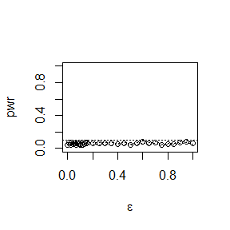

```r
library(MASS)
d <- 2
k <- 30
m <- 500
epsilon <- c(seq(0, .15, .01), seq(.15, 1, .05))
N <- length(epsilon)
pwr <- numeric(N)
#critical value for the skewness test
cv_r <- qchisq(.975, d*(d+1)*(d+2)/6)
cv_l <- qchisq(.025, d*(d+1)*(d+2)/6)

#define function sk to calculate the sample skewness
sk <- function(x, k){
  x <- mvrnorm(k, mu, sigma0)
  x_bar <- colMeans(x)
  xigma <- matrix(0, d, d)

#define the maximum likelihood estimator
  for (i in 1:k){
    xigma <-  xigma + (1/k) * (x[i,]-x_bar) %o% (x[i,]-x_bar)
  }
  xigma <- solve(xigma)

#define the skewness statistic
  for (i in 1:k){
    for (j in 1:k){
      b_1d <- b_1d + ((x[i,]-x_bar) %*% xigma %*% (x[j,]-x_bar))^3
    }
  }

  chi_test <- b_1d / k^2 * k/6
  return(chi_test)
}

for (j in 1:N) {
  #for each epsilon
  e <- epsilon[j]
  sktests <- numeric(m)
  for (i in 1:m) {
    #for each replicate
    sigma <- sample(c(1, 10), replace = TRUE, size = k, prob = c(1-e, e))
    x <- rnorm(n, 0, sigma)
    sktests[i] <- as.integer(sk(x, k) >= cv_r || sk(x, k) <= cv_l)
  }
  pwr[j] <- mean(sktests)
}
#plot power vs epsilon
plot(epsilon, pwr, type = "b", xlab = bquote(epsilon), ylim = c(0,1))
abline(h = .1, lty = 3)
se <- sqrt(pwr * (1-pwr) / m) #add standard errors
lines(epsilon, pwr+se, lty = 3)
lines(epsilon, pwr-se, lty = 3)
```

## A-21041-2021-10-28

## Questions:

Exercises 7.7, 7.8, 7.9, and 7.B (pages 213, Statistical Computating with R).

## Answers:

### 7.7

```r
data(scor,package = "bootstrap")

#define sample size & number of replicates
n <- 1000
sample.size <- dim(scor)[1]
theta_hat <- numeric(n)

#get samples from dataset "scor" using bootstrap
for (i in 1:n){
  index <- sample(1:sample.size, size = sample.size, replace = T)
  data_cor <- cor(scor[index,])
  data_ev <- eigen(data_cor)$value
  data_ev_sum <- sum(data_ev)
  data_lambda <- numeric(length(data_ev))
  data_lambda_1 <- max(data_ev)
  theta_hat[i] <- data_lambda_1/data_ev_sum
}
theta_mean <- mean(theta_hat)
theta_sd <- sd(theta_hat)

#present the conclusion
knitr::kable(cbind(theta_mean,theta_sd))
```

| theta_mean | theta_sd |
| --- | --- |
| 0.6365785 | 0.0433233 |

### 7.8

```r
data(scor,package = "bootstrap")

#define sample size & number of replicates
n <- 1000
sample.size <- dim(scor)[1]
theta_hat <- numeric(n)

#get samples from dataset "scor" using bootstrap
for (i in 1:n){
  index <- sample(1:sample.size, size = sample.size, replace = T)
  data_cor <- cor(scor[index,])
  data_ev <- eigen(data_cor)$value
  data_ev_sum <- sum(data_ev)
  data_lambda <- numeric(length(data_ev))
  data_lambda_1 <- max(data_ev)
  theta_hat[i] <- data_lambda_1/data_ev_sum
}

theta.jack <- numeric(n)
for (i in 1:n){
  theta.jack[i] = mean(theta_hat[-i])
}
bias.jack <- (n-1)*(mean(theta.jack)-theta_hat)
sd_jack <- sqrt((n-1)*mean((theta.jack-mean(theta_hat))^2))
theta_bias <- mean(bias.jack)

#present the conclusion
knitr::kable(cbind(theta_bias, sd_jack))
```

| theta_bias | sd_jack |
| --- | --- |
| 0 | 0.0013294 |

### 7.9

#### Percentile

```r
library(boot)
data(scor,package = "bootstrap")

#define sample size & number of replicates
n <- 1000
sample.size <- dim(scor)[1]
theta_hat <- numeric(n)

#get samples from dataset "scor" using bootstrap
for (i in 1:n){
  index <- sample(1:sample.size, size = sample.size, replace = T)
  data_cor <- cor(scor[index,])
  data_ev <- eigen(data_cor)$value
  data_ev_sum <- sum(data_ev)
  data_lambda <- numeric(length(data_ev))
  data_lambda_1 <- max(data_ev)
  theta_hat[i] <- data_lambda_1/data_ev_sum
}

c1 = quantile(theta_hat,0.025)
c2 = quantile(theta_hat,0.975)
print(rbind(c(c1,c2)))
```

```
##          2.5%     97.5%
## [1,] 0.544174 0.7129965
```

```r
library(boot)
data(scor,package = "bootstrap")

#define sample size & number of replicates
n <- 1000
sample.size <- dim(scor)[1]
theta_hat <- numeric(n)

#get samples from dataset "scor" using bootstrap
for (i in 1:n){
  index <- sample(1:sample.size, size = sample.size, replace = T)
  data_cor <- cor(scor[index,])
  data_ev <- eigen(data_cor)$value
  data_ev_sum <- sum(data_ev)
  data_lambda <- numeric(length(data_ev))
  data_lambda_1 <- max(data_ev)
  theta_hat[i] <- data_lambda_1/data_ev_sum
}

c1 = quantile(theta_hat,0.025)
c2 = quantile(theta_hat,0.975)
print(rbind(c(c1,c2)))
```

```
##           2.5%     97.5%
## [1,] 0.5444295 0.7171839
```

### 7.B

```r
#define a function to compute the sample skewness
skewness <- function(x){
  xbar <- mean(x)
  m3 <- mean((x-xbar)^3)
  m2 <- mean((x-xbar)^2)
  return( m3 / m2^1.5 )
}

library(boot)
mu <- 0  # the skewness of normal populations
n <- 20  # the sample size in bootstrap
m <- 1e3 # replicate time in Monte Carlo experiments

boot.skew <- function(x,i) {
  skewness(x[i])
}

ci.norm <- ci.basic <- ci.perc <- matrix(NA,m,2)
for(i in 1:m){
  X <- rnorm(n,mean = 0,sd = 1)
  de <- boot(data = X, statistic = boot.skew, R = 1e3)
  ci <- boot.ci(de,type = c("norm","basic","perc"))
  ci.norm[i,] <- ci$norm[2:3]
  ci.basic[i,] <- ci$basic[4:5]
  ci.perc[i,] <- ci$percent[4:5]
}

cover.prob <- c(mean(ci.norm[,1]<= mu & ci.norm[,2]>= mu),
                mean(ci.basic[,1]<= mu & ci.basic[,2]>= mu),
                mean(ci.perc[,1]<= mu & ci.perc[,2]>= mu))

left.omit <- c(mean(ci.norm[,1]>= mu),
               mean(ci.basic[,1]>= mu),
               mean(ci.perc[,1]>= mu))

right.omit <- c(mean(ci.norm[,2]<= mu),
               mean(ci.basic[,2]<= mu),
               mean(ci.perc[,2]<= mu))
cover.norm <- matrix(data = c(cover.prob,left.omit,right.omit),nrow = 3,byrow = TRUE,)
rownames(cover.norm) <- c("cover probability","miss on the left","miss on the right")
colnames(cover.norm) <- c("standard normal bootstrap confidence interval","basic bootstrap confidence interval","percentile bootstrap confidence interval")

knitr::kable(t(cover.norm))
```

|  | cover probability | miss on the left | miss on the right |
| --- | --- | --- | --- |
| standard normal bootstrap confidence interval | 0.907 | 0.046 | 0.047 |
| basic bootstrap confidence interval | 0.900 | 0.048 | 0.052 |
| percentile bootstrap confidence interval | 0.978 | 0.013 | 0.009 |

```r
library(boot)
mu <- sqrt(8/5)  # the skewness of chi-squared distribution
n <- 20  # the sample size in bootstrap
m <- 1e3 # replicate time in Monte Carlo experiments

boot.skew <- function(x,i){
  skewness(x[i])
}

ci.norm <- ci.basic <- ci.perc <- matrix(NA,m,2)

for(i in 1:m){
  X <- rchisq(n,df = 5)
  de <- boot(data = X, statistic = boot.skew, R = 1e3)
  ci <- boot.ci(de,type = c("norm","basic","perc"))
  ci.norm[i,] <- ci$norm[2:3]
  ci.basic[i,] <- ci$basic[4:5]
  ci.perc[i,] <- ci$percent[4:5]
}


cover.prob <- c(mean(ci.norm[,1]<= mu & ci.norm[,2]>= mu),
                mean(ci.basic[,1]<= mu & ci.basic[,2]>= mu),
                mean(ci.perc[,1]<= mu & ci.perc[,2]>= mu))
left.omit <- c(mean(ci.norm[,1]>= mu),
               mean(ci.basic[,1]>= mu),
               mean(ci.perc[,1]>= mu))
right.omit <- c(mean(ci.norm[,2]<= mu),
               mean(ci.basic[,2]<= mu),
               mean(ci.perc[,2]<= mu))

cover.chisq <- matrix(data = c(cover.prob,left.omit,right.omit),nrow = 3,byrow = TRUE,)
rownames(cover.chisq) <- c("cover probability","miss on the left","miss on the right")
colnames(cover.chisq) <- c("standard normal bootstrap confidence interval","basic bootstrap confidence interval","percentile bootstrap confidence interval")

knitr::kable(t(cover.chisq))
```

|  | cover probability | miss on the left | miss on the right |
| --- | --- | --- | --- |
| standard normal bootstrap confidence interval | 0.729 | 0.023 | 0.248 |
| basic bootstrap confidence interval | 0.691 | 0.054 | 0.255 |
| percentile bootstrap confidence interval | 0.725 | 0.000 | 0.275 |

## A-21041-2021-11-04

## Questions:

Exercise 8.2 (page 242, Statistical Computating with R).

Design experiments for evaluating the performance of the NN, energy, and ball methods in various situations. I Unequal variances and equal expectations I Unequal variances and unequal expectations I Non-normal distributions: t distribution with 1 df (heavy-tailed distribution), bimodel distribution (mixture of two normal distributions) I Unbalanced samples (say, 1 case versus 10 controls) I Note: The parameters should be chosen such that the powers are distinguishable (say, range from 0.3 to 0.8)

## Answers:

### 8.2

The Spearman rank correlation statistic is
$$\rho=\frac{\sum_{i=1}^n R(x_i)R(y_i) - n(\frac{n+1}{2})^2}{\sqrt{\sum_{i=1}^n R^2(x_i) - n(\frac{n+1}{2})^2}\sqrt{\sum_{i=1}^n R^2(y_i) - n(\frac{n+1}{2})^2}}$$

```r
# part A: cor.test
#randomly generating x & y as the samples
x <- c(70, 78, 78, 87, 84, 87, 90)
y <- c(71, 77, 79, 86, 84, 90, 78)

#calculate Spearman rank correlation and return the p-value
a <- cor.test(x, y, method = "spearman")
p <- a$p.value


# part B: permutation.test
# form the data
n <- 10000
z <- c(x,y)

rho <- function(s,t){
  m <- length(s)
  Rx <- rank(s, ties.method = "average")
  Ry <- rank(t, ties.method = "average")

  for (i in 1:m) {
    rho1 = sum(Rx[i] * Ry[i]) - m * ((m+1)/2)^2
    rho2 = sum(Rx[i]^2) - m * ((m+1)/2)^2
    rho3 = sum(Ry[i]^2) - m * ((m+1)/2)^2
  }
  rho1/sqrt(rho2 * rho3)
}


rho_init <- rho(x,y)

# randomly choosing data from z
S <- S1 <- S2 <- rho_per <- numeric(n)
for (i in 1:n) {
  S <- sample(z, size = 14,replace = FALSE)
  S1 <- S[1:7]
  S2 <- S[8:14]
  rho_per[i] <- rho(S1,S2)
}

p_perm <- mean(rho_per < rho_init)

knitr::kable(cbind(p, p_perm))
```

| p | p_perm |
| --- | --- |
| 0.154291 | 0.1268 |

## design task

### (1) generate two different distribution with Unequal variances and equal expectations

```r
library(RANN)
library(boot)
library(Ball)
library(energy)
library(MASS)

#define functions to calculate the power using different methods
tnn <- function(z, ix, sizes,k) {
  n1 <- sizes[1]
  n2 <- sizes[2]
  n <- n1 + n2
  if(is.vector(z))
    z <- data.frame(z,0);
    z <- z[ix, ];
    NN <- nn2(data=z, k=k+1)

  block1 <- NN$nn.idx[1:n1, -1]
  block2 <- NN$nn.idx[(n1+1):n, -1]
  i_1 <- sum(block1 < n1 + .5)
  i_2 <- sum(block2 > n1+.5)
  (i_1 + i_2) / (k * n)
}

eqdist.nn <- function(z,sizes,k){
  boot.obj <- boot(data=z,statistic = tnn,R = R, sim = "permutation", sizes = sizes,k=k)
  ts <- c(boot.obj$t0,boot.obj$t)
  p.value <- mean(ts>=ts[1])
  list(statistic=ts[1],p.value=p.value)
}


set.seed(10101)
k <- 2
R <- 1500
m <- 100
n_1 <- n_2 <- 20
n <- n_1 + n_2
N <- c(n_1, n_2)

#giving the parameters of two different distributions
mu_1 <- mu_2 <- c(0,0)
sigma_1 <- matrix(c(1,0,0,1), nrow = 2, ncol = 2)
sigma_2 <- matrix(c(1,0,0,2), nrow = 2, ncol = 2)

p.values <- matrix(NA,m,3)

for(i in 1:m){
  data1 <- mvrnorm(n_1, mu_1, sigma_1)
  data2 <- mvrnorm(n_2, mu_2, sigma_2)
  data <- rbind(data1, data2)

  # using nn method
  p.values[i,1] <- eqdist.nn(data,N,k)$p.value
  # using energy method
  p.values[i,2] <- eqdist.etest(data,sizes=N,R=R)$p.value
  # using ball method
  p.values[i,3] <- bd.test(x=data1, y=data2, num.permutations=R, seed=i*2846)$p.value
}
alpha <- 0.05;
power <- colMeans(p.values < alpha)
power
```

```
## [1] 0.1 0.1 0.2
```

### (2) generate two different distribution with Unequal variances and unequal expectations

```r
library(RANN)
library(boot)
library(Ball)
library(energy)
library(MASS)

#define functions to calculate the power using different methods
tnn <- function(z, ix, sizes,k) {
  n1 <- sizes[1]
  n2 <- sizes[2]
  n <- n1 + n2
  if(is.vector(z))
    z <- data.frame(z,0);
    z <- z[ix, ];
    NN <- nn2(data=z, k=k+1)

  block1 <- NN$nn.idx[1:n1, -1]
  block2 <- NN$nn.idx[(n1+1):n, -1]
  i_1 <- sum(block1 < n1 + .5)
  i_2 <- sum(block2 > n1+.5)
  (i_1 + i_2) / (k * n)
}

eqdist.nn <- function(z,sizes,k){
  boot.obj <- boot(data=z,statistic = tnn,R = R, sim = "permutation", sizes = sizes,k=k)
  ts <- c(boot.obj$t0,boot.obj$t)
  p.value <- mean(ts>=ts[1])
  list(statistic=ts[1],p.value=p.value)
}


set.seed(10101)
k <- 2
R <- 1500
m <- 100
n_1 <- n_2 <- 20
n <- n_1 + n_2
N <- c(n_1, n_2)

#giving the parameters of two different distributions
mu_1 <- c(0,0)
mu_2 <- c(1,-1)
sigma_1 <- matrix(c(1,0,0,1), nrow = 2, ncol = 2)
sigma_2 <- matrix(c(1,0,0,2), nrow = 2, ncol = 2)

p.values <- matrix(NA,m,3)

for(i in 1:m){
  data1 <- mvrnorm(n_1, mu_1, sigma_1)
  data2 <- mvrnorm(n_2, mu_2, sigma_2)
  data <- rbind(data1, data2)

  # using nn method
  p.values[i,1] <- eqdist.nn(data,N,k)$p.value
  # using energy method
  p.values[i,2] <- eqdist.etest(data,sizes=N,R=R)$p.value
  # using ball method
  p.values[i,3] <- bd.test(x=data1, y=data2, num.permutations=R, seed=i*2846)$p.value
}
alpha <- 0.05;
power <- colMeans(p.values < alpha)
power
```

```
## [1] 0.67 0.96 0.91
```

### (3)Non-normal distributions: t distribution with 1 df (heavy-tailed distribution), bimodel distribution (mixture of two normal distributions)

#### we generate a bimodel distribution:

```r
n1 <- n2 <- 20
n <- n1+n2
N = c(n1,n2)
k=3
R=1500
m=100
set.seed(10101)
p.values <- matrix(NA,m,3)
for(i in 1:m){
  mydata1 <- as.matrix(rt(n1,1,2),ncol=1)
  mydata2 <- as.matrix(rt(n2,2,5),ncol=1)
  mydata <- rbind(mydata1,mydata2)
  p.values[i,1] <- eqdist.nn(mydata,N,k)$p.value
  p.values[i,2] <- eqdist.etest(mydata,sizes=N,R=R)$p.value
  p.values[i,3] <- bd.test(x=mydata1,y=mydata2,num.permutations=R,seed=i*2846)$p.value
}
alpha <- 0.05;
pow <- colMeans(p.values<alpha)
pow
```

```
## [1] 0.65 0.43 0.78
```

#### The result suggests that for bimodel distributions, the ball method performs the best, while the energy method performs worst.

4. Unbalanced samples:

```r
mu_1 <- c(0,0)
mu_2 <- c(1,-1)
sigma_1 <- matrix(c(1,0,0,1), nrow = 2, ncol = 2)
sigma_2 <- matrix(c(1,0,0,2), nrow = 2, ncol = 2)
n_1 = 10
n_2 = 100
n <- n_1+n_2
N = c(n_1,n_2)
k <- 3
R <- 1500
m <- 100
set.seed(1234)
p.values <- matrix(NA,m,3)
for(i in 1:m){
  mydata1 <- mvrnorm(n_1,mu_1,sigma_1)
  mydata2 <- mvrnorm(n_2,mu_2,sigma_2)
  mydata <- rbind(mydata1,mydata2)
  p.values[i,1] <- eqdist.nn(mydata,N,k)$p.value
  p.values[i,2] <- eqdist.etest(mydata,sizes=N,R=R)$p.value
  p.values[i,3] <- bd.test(x=mydata1, y=mydata2, num.permutations=R, seed=i*2846)$p.value
}
alpha <- 0.05;
pow <- colMeans(p.values<alpha)
pow
```

```
## [1] 0.30 0.92 0.85
```

#### The result suggests that the energy method performs the best, while the nn method performs much worse than the other two.

## from the above four situations, we conclude that different method is efficient in different field, there is no such a widly useful way to solve all the problems.

## A-21041-2021-11-11

Exercies 9.3 Exercies 9.8

For each of the above exercise, use the Gelman-Rubin method to monitor convergence of the chain, and run the chain until it converges approximately to the target distribution according to $\hat{R}<1.2$

## Answers:

### 9.3

Take x0=15 and $\sigma=c(0.05,0.5,1,16)$ as an example

```r
set.seed(10101)
rw.Metropolis <- function(mu,lambda,sigma,x0,N){
  x <- numeric(N)
  x[1] <- x0
  u <- runif(N)
  k <- 0
  for (i in 2:N) {
    y <- rnorm(1,x[i-1],sigma)

      #用dcauchy来计算cauchy分布在给定点处的密度函数值
      if(u[i] <= (dcauchy(y,mu,lambda)/dcauchy(x[i-1], mu, lambda)))
        x[i] <- y
      else{
        x[i] <- x[i-1]
        k <- k+1
      }
  }
  return(list(x=x,k=k))
}

#给柯西分布的参数、提议分布的方差以及初始值x0赋值
mu <- 0; lambda <- 1
N <- 4000
sigma <- c(0.05,0.5,1,16)
x0 <- 15

#生成不同方差下的四个链
rw1 <- rw.Metropolis(mu,lambda, sigma[1], x0, N)
rw2 <- rw.Metropolis(mu,lambda, sigma[2], x0, N)
rw3 <- rw.Metropolis(mu,lambda, sigma[3], x0, N)
rw4 <- rw.Metropolis(mu,lambda, sigma[4], x0, N)

#计算每个链中待选点的拒绝率
print(c(rw1$k,rw2$k,rw3$k,rw4$k)/N)
```

```
## [1] 0.00200 0.05175 0.22975 0.80475
```

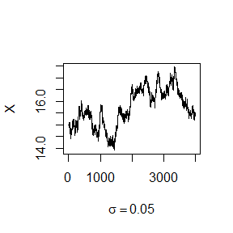

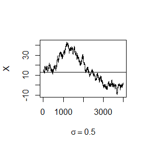

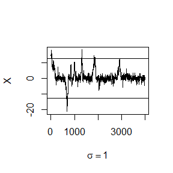

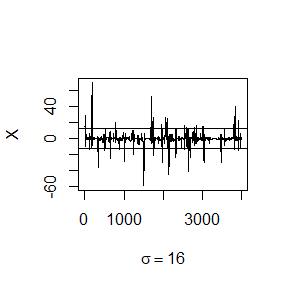

```r
#绘制四个链的轨迹图
#par(mfrow = c(2,2))
refline <- qcauchy(c(.025,.975), mu, lambda)
rw <- cbind(rw1$x,rw2$x,rw3$x,rw4$x)
for (j in 1:4) {
  plot(rw[,j],type='l',xlab=bquote(sigma==.(round(sigma[j],3))),
       ylab='X',ylim=range(rw[,j]))
  abline(h=refline)
}
```

[figure not shown]

```r
par(mfrow=c(1,1))

#丢弃链的前1000个值
rw_new1 <- rw1$x[1001:4000]
rw_new2 <- rw2$x[1001:4000]
rw_new3 <- rw3$x[1001:4000]
rw_new4 <- rw4$x[1001:4000]

#计算理论及丢弃前1000个值后的四组链值的十分位数
probs <- c(0.1,0.2,0.3,0.4,0.5,0.6,0.7,0.8,0.9)
df <- qcauchy(probs,mu,lambda)
df1 <- quantile(rw_new1,probs)
df2 <- quantile(rw_new2,probs)
df3 <- quantile(rw_new3,probs)
df4 <- quantile(rw_new4,probs)

#绘制理论十分位数折线及四个链的十分位数点
plot(df~probs, pch = 21, col="black",xlab = "分位数",
     xlim = c(0.1,0.9), ylab="十分位数值", ylim = c(-5,5),
     main="理论及四组链值的十分位数折线图",type = "l")
points(probs, df1, pch= 22, col="blue", cex=1)
points(probs, df2, pch= 23, col="red", cex=1)
points(probs, df3, pch= 24, col="pink", cex=1)
points(probs, df4, pch= 25, col="green", cex=1)

legend("topleft", inset=.05, c("理论","方差0.05","方差0.5","方差1","方差16"),
       col=c("black","blue","red","pink","green"),
       text.col=c("black","blue","red","pink","green"),
       pch=c(21,22,23,24,25))
```

In the first plot with σ = 0.05, the Chain 1 has not converged to the target in 4000 iterations. The chain 2 in the second plot generated with σ = 0.5 is converging very slowly and requires a much longer burn-in period. In the third plot (σ = 1) the chain is mixing well and converging to the target distribution after a burn-in period of about 1700. Finally, in the fourth plot, where σ = 16, the chain 4 converges, but it is inefficient.

### 9.8

Use the Gibbs sampler to generate a chain with target joint density f(x, y), take [a = 100, b = 100, n = 1000, x0 = 100, y0 = 0.5] as my example, the R code is as follow:

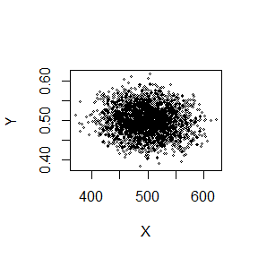

```r
#initialize constants
set.seed(10101)
N <- 4000 #length of chain
burn_period <- 1000 #burn-in length
X <- matrix(0, N, 2) #the chain, a bivariate sample
x <- y <- numeric(N)
#initialize the parameters
a <- 100
b <- 100
n <- 1000

#initialize the variate's value
X[1, 1] <- 100
X[1, 2] <- 0.5

#generate the chain
for (i in 2:N){
  x[i] <- X[i-1, 1]
  y[i] <- X[i-1, 2]
  X[i, 1] <- rbinom(1, n, y[i])
  X[i, 2] <- rbeta(1, x[i]+a, n-x[i]+b)
}
b <- burn_period + 1
m <- X[b:N,]

plot(m, main="", cex=.4, xlab="X",
ylab="Y", xlim=range(m[,1]), ylim=range(m[,2]))
```

#### The result is as the figure shows

### 9.3plus

```r
set.seed(10101)

Gelman.Rubin <- function(psi) {
  # psi[i,j] is the statistic psi(X[i,1:j])
  # for chain in i-th row of X
  psi <- as.matrix(psi)
  n <- ncol(psi)
  k <- nrow(psi)
  psi.means <- rowMeans(psi) #row means
  B <- n * var(psi.means) #between variance est.
  psi.w <- apply(psi, 1, "var") #within variances
  W <- mean(psi.w) #within est.
  v.hat <- W*(n-1)/n + (B/n) #upper variance est.
  r.hat <- v.hat / W #G-R statistic
  return(r.hat)
}

normal.chain <- function(mu, lambda, sigma, N, X1) {
  #generates a Metropolis chain for Normal(0,1)
  #with Normal(X[t], sigma) proposal distribution
  #and starting value X1
  x <- numeric(N)
  x[1] <- X1
  u <- runif(N)
  for (i in 2:N) {
    y <- rnorm(1,x[i-1],sigma)
      #用dcauchy来计算cauchy分布在给定点处的密度函数值
      if(u[i] <= (dcauchy(y,mu,lambda)/dcauchy(x[i-1], mu, lambda)))
        x[i] <- y
      else{
        x[i] <- x[i-1]
      }
  }
  return(x)
}

mu <- 0      #parameter of cauchy distribution
lambda <- .01  #parameter of cauchy distribution
sigma <- 1   #parameter of proposal distribution
k <- 4       #number of chains to generate
n <- 20000   #length of chains
b <- 2000    #burn-in length


#choose overdispersed initial values
x0 <- c(-5, 0, 10, 25)
#generate the chains
X <- matrix(0, nrow=k, ncol=n)
for (i in 1:k)
  X[i, ] <- normal.chain(mu, lambda, sigma, n, x0[i])

#compute diagnostic statistics
psi <- t(apply(X, 1, cumsum))
for (i in 1:nrow(psi))
  psi[i,] <- psi[i,] / (1:ncol(psi))
print(Gelman.Rubin(psi))
```

```
## [1] 1.177011
```

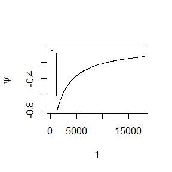

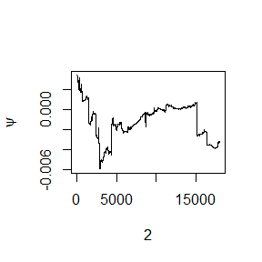

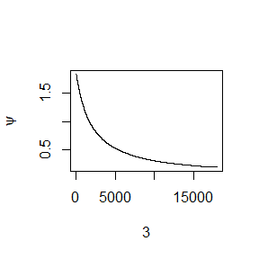

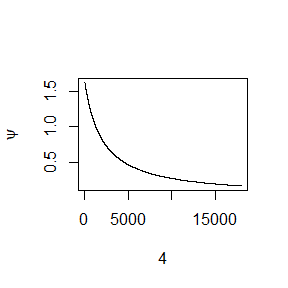

```r
#plot psi for the four chains
#par(mfrow=c(2,2))
for (i in 1:k)
  plot(psi[i, (b+1):n], type="l", xlab=i, ylab=bquote(psi))
```

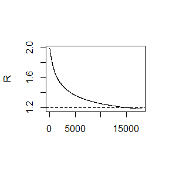

```r
par(mfrow=c(1,1)) #restore default

#plot the sequence of R-hat statistics
rhat <- rep(0, n)
for (j in (b+1):n)
  rhat[j] <- Gelman.Rubin(psi[,1:j])
plot(rhat[(b+1):n], type="l", xlab="", ylab="R")

#give the line of R_hat = 1.2
abline(h=1.2, lty=2)
```

### 9.8plus

```r
library(R2OpenBUGS)
library(coda)

set.seed(10101)

N <- 4000 #length of chain
burn_period <- 1000 #burn-in length
X <- matrix(0, N, 2) #the chain, a bivariate sample
x <- y <- numeric(N)
#initialize the parameters
a <- 100
b <- 100
n <- 1000

#initialize the variate's value
X[1, 1] <- 100
X[1, 2] <- 0.5

#generate the chain
for (i in 2:N){
  x[i] <- X[i-1, 1]
  y[i] <- X[i-1, 2]
  X[i, 1] <- rbinom(1, n, y[i])
  X[i, 2] <- rbeta(1, x[i]+a, n-x[i]+b)
}
b <- burn_period + 1
m <- X[b:N,]

R <- 10000
y <- m[,2]
data <- list ("N", "R", "y")

inits <- function(){
  list(theta = rnorm(N, 0, 100), mu.theta = rnorm(1, 0, 100),
    sigma.theta = runif(1, 0, 100))
}

model{
  for (j in 1:R)
  {
    y[j] ~ dnorm (theta[j], tau.y[j])
    theta[j] ~ dnorm (mu.theta, tau.theta)
    tau.y[j] <- pow(sigma.y[j], -2)
  }
  mu.theta ~ dnorm (0.0, 1.0E-6)
  tau.theta <- pow(sigma.theta, -2)
  sigma.theta ~ dunif (0, N)
}


lattice::xyplot(myModel.coda[,2:4])

plot(myModel.coda[,2:4])

acfplot(myModel.coda[,2:4], lag.max=200)
gelman.plot(myModel.coda[,2:4])
```

fail to obtain a conclusion

## A-21041-2021-11-18

## Questions:

Exercises 11.3 and 11.5 (pages 353-354, Statistical Computing with R) I Suppose T1, . . . , Tn are i.i.d. samples drawn from the exponential distribution with expectation λ. Those values greater than τ are not observed due to right censorship, so that the observed values are Yi = TiI(Ti ≤ τ) + τI(Ti > τ), i = 1, . . . , n. Suppose τ = 1 and the observed Yi values are as follows: 0.54, 0.48, 0.33, 0.43, 1.00, 1.00, 0.91, 1.00, 0.21, 0.85 Use the E-M algorithm to estimate λ, compare your result with the observed data MLE (note: Yi follows a mixture distribution)

## Solutions

### 11.3

```r
Euclid <- function(x){
  sqrt(sum(x^2))
}


term_k <- function(a, k){
  d <- length(a)
  (-1)^k/(factorial(k)*2^k) * (Euclid(a))^(2*k+2)/((2*k+1)*(2*k+2)) * gamma((d+1)/2)*gamma(k+1.5)/gamma(k+d/2+1)
}




S <- function(a){
  sum <- 0
  k <- 0
  c <- 1
  while(abs(c) > 1e-100){
    #print(term_k(a, k))
    sum <- sum + term_k(a, k)
    k = k + 1
    c <- term_k(a, k)
  }
  return(sum)
}




a <- c(1,2)
S(a)
```

```
## [1] 1.532164
```

As is showed above , the sum when a = (1, 2) is 1.532164

### 11.5

首先，我们对等式两边同时取对数，这不改变方程的根(积分用integ1/2代替)
$$log2 + log\Gamma(k/2)-\frac{1}{2}log\pi - \frac{1}{2}log(k-1) - log\Gamma(\frac{k-1}{2}) - log(integ1) \\
= log2 + log\Gamma((k+1)/2)-\frac{1}{2}log\pi - \frac{1}{2}log(k) - log\Gamma(\frac{k}{2}) - log(integ2)$$
也即
$$(log(k) - log(k-1))/2 + (2log\Gamma(k/2) - log\Gamma((k+1)/2)- log\Gamma((k-1)/2)) +log(integ1) - log(integ2) = 0$$

```r
c_k <- function(a, k){
  sqrt(a^2*k / (k+1-a^2))
}


inted = function(k,u){
  (1+u^2/k)^(-(k+1)/2)
}


equation11_5 <- function(a, k){
   (log(k) - log(k-1))/2 + (2*lgamma(k/2) - lgamma((k+1)/2)- lgamma((k-1)/2)) + log(integrate(inted, 0, c_k(a, k-1), k = k-1)$value) - log(integrate(inted, 0, c_k(a, k), k = k)$value)
}


root11_5 <- sapply(c(4:25,100,500,1000), function(k){uniroot(equation11_5, interval = c(1, 2), k=k)$root})

#root11_5 <- sapply(c(4:25,100,500,1000),function(k){uniroot(equation11_5, interval = c(0, sqrt(k)))$root})


equation11_4 <- function(a, k){
  pt(c_k(a, k-1), df = k-1) - pt(c_k(a, k), df = k)
}

root11_4 <- sapply(c(4:25,100,500,1000), function(k){uniroot(equation11_4, interval = c(1, 2), k=k)$root})

#root11_4 <- sapply(c(4:25,100,500,1000),function(k){uniroot(equation11_5, interval = c(0, sqrt(k)))$root})


root <- cbind(root11_5, root11_4)
colnames(root) <- c("root in 11.5", "root in 11.4")
rownames(root) <- as.character(c(4:25,100,500,1000))

knitr::kable(root)
```

|  | root in 11.5 | root in 11.4 |
| --- | --- | --- |
| 4 | 1.492088 | 1.492103 |
| 5 | 1.533559 | 1.533556 |
| 6 | 1.562747 | 1.562744 |
| 7 | 1.584435 | 1.584430 |
| 8 | 1.601193 | 1.601185 |
| 9 | 1.614533 | 1.614521 |
| 10 | 1.625405 | 1.625390 |
| 11 | 1.634436 | 1.634419 |
| 12 | 1.641997 | 1.642038 |
| 13 | 1.648515 | 1.648554 |
| 14 | 1.654154 | 1.654190 |
| 15 | 1.659080 | 1.659114 |
| 16 | 1.663420 | 1.663452 |
| 17 | 1.667273 | 1.667304 |
| 18 | 1.670716 | 1.670745 |
| 19 | 1.673812 | 1.673840 |
| 20 | 1.676611 | 1.676637 |
| 21 | 1.679153 | 1.679178 |
| 22 | 1.681471 | 1.681496 |
| 23 | 1.683594 | 1.683620 |
| 24 | 1.685546 | 1.685572 |
| 25 | 1.687347 | 1.687373 |
| 100 | 1.720599 | 1.720608 |
| 500 | 1.729745 | 1.729756 |
| 1000 | 1.730897 | 1.730908 |

可以看到，11.5和11.4算出的根很接近。

### EM算法

对于估测值$Y_i$，令随机变量$Y$具有分布函数$F_Y$,则
$$\begin{aligned}
F_Y(y)
&= P(Y \leq y) \\
&= P(T I(T \leq \tau) + \tau I(T>\tau) \leq y) \\
&= P(T \leq \tau) P(T \leq y) + P(T>\tau)P(\tau \leq y) \\
&= 0.7P(T \leq y) + 0.3P(1 \leq y) \\
&= 0.7 \int_0^y \lambda e^{-\lambda x}dx + 0.3 P(1 \leq y)
\end{aligned}$$
当$y>1$时，有
$$F_Y(y) = 1-0.7e^{-\lambda y}$$
当$0 < y \leq 1$时，有
$$F_Y(y) = 0.7-0.7e^{-\lambda y}$$
易知：
$$f(y)=0.7 \lambda e^{-\lambda y},y>0$$
因此，观测值的似然函数为
$$f(\pmb{y}|\lambda)=0.7^{10} \lambda e^{-\lambda \sum_{i=1}^{10} y_i}$$
容易求得，$\lambda$的极大似然为
$$\hat{\lambda} = \frac{1}{\sum_{i=1}^{10} y_i} = 0.1481481$$
EM算法步骤： 初始化$\lambda^{(1)}$,令
$$Z_i=\sum_{i=1}^{10}I(y_i<1)$$
则根据样本得到的似然函数为
$$\begin{aligned}
f(\pmb{y}|\lambda_1)
&\propto \lambda^{Z_i} e^{-\lambda \sum_{i=1}^{10} y_iI(y_i<1)} (\int_1^{\infty} \lambda e^{-\lambda t} dt)^{10-Z_i} \\
&= \lambda^{Z_i}e^{-3.75\lambda} (e^{-\lambda_1})^{10-Z_i}
\end{aligned}$$
假设$\lambda$的先验分布为均匀分布，则
$$\pi(\lambda|\pmb{y}) \propto \lambda^{Z_i}e^{-3.75\lambda} (e^{-\lambda})^{10-Z_i}$$
E步：
$$Q(\lambda, \lambda^{(i)})= E[Z_iln\lambda-3.75\lambda -10\lambda+\lambda Z_i|\lambda^{(i)},\pmb{y}]$$
M步为最大化Q，为此求导并令为0，得：
$$\hat{\lambda}^{(i+1)} = \frac{E[Z_i]}{13.75-E[Z_i]}$$
其中，$Z \sim B(10,p),\quad p = \int_0^1 \hat{\lambda}^{(i)}e^{-\hat{\lambda}^{(i)} t}dt = 1-e^{-\hat{\lambda}^{(i)}}$，故$E[Z_i] = 10-10e^{-\hat{\lambda}^{(i)}}$，代入
$$\hat{\lambda}^{(i+1)} = \frac{10-10e^{-\hat{\lambda}^{(i)}}}{13.75-10+10e^{-\hat{\lambda}^{(i)}}} = \frac{10e^{\hat{\lambda}^{(i)}}-10}{3.75e^{\hat{\lambda}^{(i)}}+10}$$
迭代10次得到：

```r
#初始化参数为1
lambda <- 1
i <- 1
while (i<10) {
  lambda <- (10*exp(lambda)-10)/(3.75*exp(lambda)+10)
  i = i+1
}
lambda
```

```
## [1] 0.1349839
```

这于前面所得的极大似然估计十分接近。

## A-21041-2021-11-25

## Questions:

Exercise 1 and 5(page204,Advanced R)

Exercise 1 and 7(page214,Advanced R)

## Solutions

### P204-1

```r
trims <- c(0, 0.1, 0.2, 0.5)
x <- rcauchy(100)
lapply(trims, function(trim) mean(x, trim = trim))
```

```
## [[1]]
## [1] -0.1037817
##
## [[2]]
## [1] -0.2103385
##
## [[3]]
## [1] -0.1689894
##
## [[4]]
## [1] -0.09482398
```

```r
lapply(trims, mean, x = x)
```

```
## [[1]]
## [1] -0.1037817
##
## [[2]]
## [1] -0.2103385
##
## [[3]]
## [1] -0.1689894
##
## [[4]]
## [1] -0.09482398
```

如程序所示，两个lapply所得结果相等 函数lapply的原理是遍历向量中的每个元素，并使用指定的函数处理其元素，lapply函数返回向量列表。例如,当trims是0.1,这意味着100 * 0.1 = 10位数的最大值和最小值被删除，然后取平均值。对于Lapply(trims,mean,x=x)，将给定向量trims中的元素直接作为均值函数的参数，将x作为Lapply中的其他参数。因此，不需要另外定义函数，所以得到的结果是一样的。

### P204-5

程序如下：

```r
#模型P204-3
formulas <- list(
  mpg ~ disp,
  mpg ~ I(1 / disp),
  mpg ~ disp + wt,
  mpg ~ I(1 / disp) + wt
)
#模型P204-4
rsq <- function(mod) summary(mod)$r.squared
#模型P204-5
a <- lapply(lapply(formulas, lm, data=mtcars), rsq)
#输出各个R平方
a
```

```
## [[1]]
## [1] 0.7183433
##
## [[2]]
## [1] 0.8596865
##
## [[3]]
## [1] 0.7809306
##
## [[4]]
## [1] 0.8838038
```

### P214-1

#### (a)

```r
x<-data.frame(cbind(x1=seq(5,20,5),x2=c(1:4)))
vapply(x, sd, FUN.VALUE = c('a'=0))
```

```
##       x1       x2
## 6.454972 1.290994
```

如上所示，向量$x_1$的标准差为6.454972，向量$x_2$的标准差为1.290994。

#### (b)

```r
x <- data.frame(a=seq(5,25,5), b=runif(5), c=c(TRUE,FALSE,TRUE,FALSE,TRUE))
sd_1 <- vapply(x, is.numeric, logical(1))
sd_2 <- vapply(x[sd_1], sd, FUN.VALUE = c('a'=0))
knitr::kable(sd_2)
```

|  | x |
| --- | --- |
| a | 7.9056942 |
| b | 0.2752602 |

结果如上

### P214-7

```r
#define the fuction of mcvapply
mcvapply <- function (cl = NULL, X, fun, ..., chunk.size = NULL) {
    cl <- defaultCluster(cl)
    nchunks <- staticNChunks(length(X), length(cl), chunk.size)
    do.call(c, clusterApply(cl = cl, x = splitList(X, nchunks),
        fun = sapply, FUN = fun, ...), quote = TRUE)
}
```

## A-21041-2021-12-02

```
library(Rcpp)
library(microbenchmark)

cppFunction('NumericMatrix gibbsC(int N, int n,int a,int b) {
  NumericMatrix mat(N, 2);
  double x = 0, y = 0;
  for(int i = 1; i < N; i++) {
    y=mat(i-1,1);
    mat(i,0)=rbinom(1, n, y)[0];
    x=mat(i,0);
    mat(i,1)=rbeta(1, x+a, n-x+b)[0];
  }
  return(mat);
}')

#pure R
set.seed(10101)
a <- 10101
b <- a+1
for (i in 1:9){
  b = i+1
}

gibbsR_R <- function(N, n, a, b) {
  mat <- matrix(nrow = N, ncol = 2)
  mat[1,] <- c(0,0)
  mat
  for (i in 2:N) {
    y <- mat[i-1,2]
    mat[i,1] <- rbinom(1,n,y)
    x <- mat[i,1]
    mat[i,2]<-rbeta(1, x+a, n-x+b)
  }
  mat
}
```